# Презентация по первому этапу индивидуального проекта.

Дисциплина: операционные системы.

Лобанова П. И.

Российский университет дружбы народов, Москва, Россия

Факультет физико-математических и естественных наук

24.02.2023

# Информация

## Докладчик

- Лобанова Полина Иннокентьевна
- Студентка факультета физико-математических и естественных наук
- Учащаяся на направлении “Математика и механика”
- Российский университет дружбы народов
- polla-2004@mail.ru

# Ход работы

## Установка файла hugo

Для начала нам необходимо установить исполняемый файл hugo, разархивировать его и переместить в нужной каталог.

[figure not shown]

*Файл hugo.*

## Создание репозитория

Далее нужно было создать новый репозиторий на основе шаблона с произвольным названием и клонировать его в наш рабочий каталог.

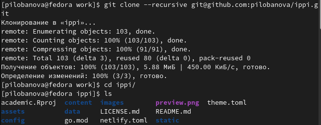

*Клонирование репозитория.*

## Ссылка на сайт

Далее выполнив несколько необходимых команд, мы получили ссылку на наш сайт, однако зайти на него возможно только с одного устройства.

[figure not shown]

*Сайт.*

## Создание нового репозитория

Чтобы сделать сайт доступный всем, необходимо было создать еще один репозиторий с конкретным названием. Выполнив несколько промежуточных действий нам нужно было привязать его к определенному каталогу в нашем рабочем каталоге.

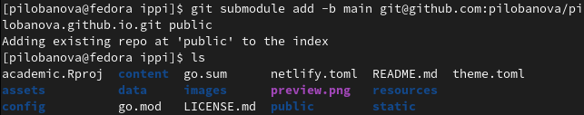

*Прикрепление репозитория к каталогу.*

## Генерация необходимых файлов

Чтобы мы могли работать с сайтом через этот каталог, необходимо создать нужные файлы, используя исполняемый файл hugo.

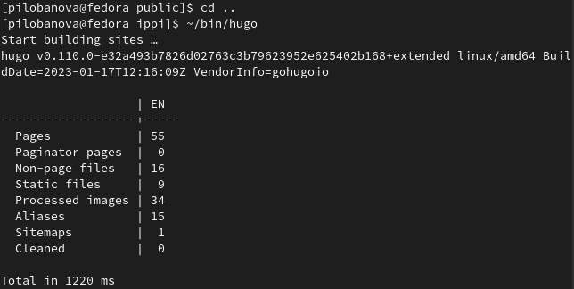

*Генерация файлов.*

## Загрузка на Github

Последним этапом работы является загрузка всех файлов на github и проверка работы сайта.

[figure not shown]

*Репозиторий на github.*

# Вывод

Я создала исходный сайт, который в дальнейшем буду редактировать, и сделала так, что его можно просмотреть с разных устройств, используя github.